# Analisi Temporale Granulare

Rosario Pio Gnazzo

2025-01-04

# Analisi Temporale dei Tweet-Retweet

Un idea potrebbe essere quella di osservare la distribuzione nel tempo dei post su Twitter contando il numero di occorrenze per sentiment in un dato sotto-intervallo di tempo.

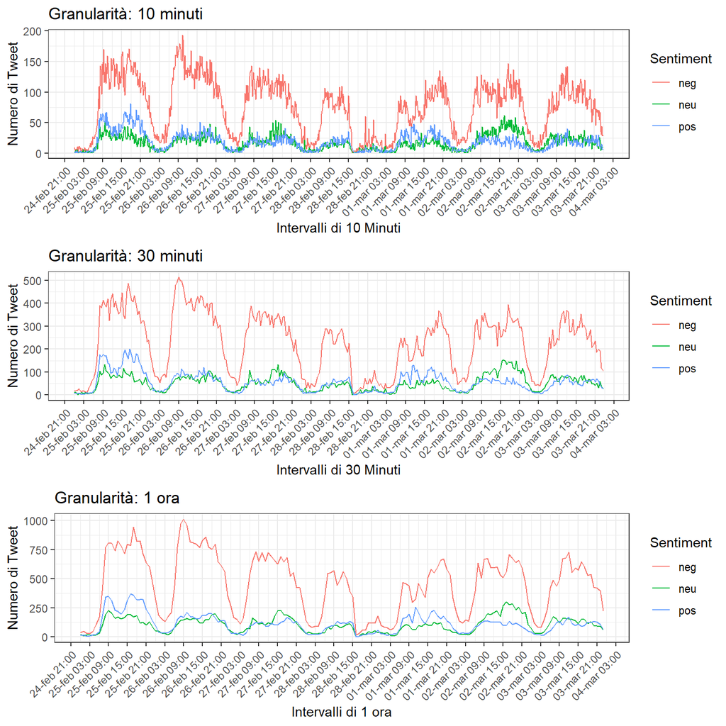

Il grafico sembra chiaramente catturare la presenza di una struttura di periodicità temporale nei dati che si preserva in tutti i livelli di analisi. Cerchiamo di osservare ancora meglio questa struttura.

## Analisi Periodicità delle serie storiche

### Tweet Negativi

#### **Granularità di 10 minuti:**

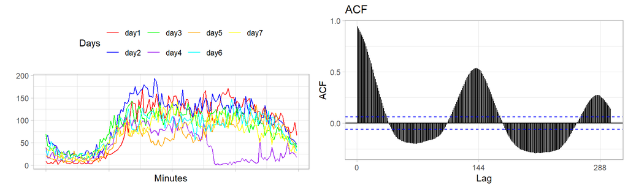

```
##
##  Box-Ljung test
##
## data:  neg_ts10
## X-squared = 896.73, df = 1, p-value < 2.2e-16
```

#### **Granularità di 30 minuti:**

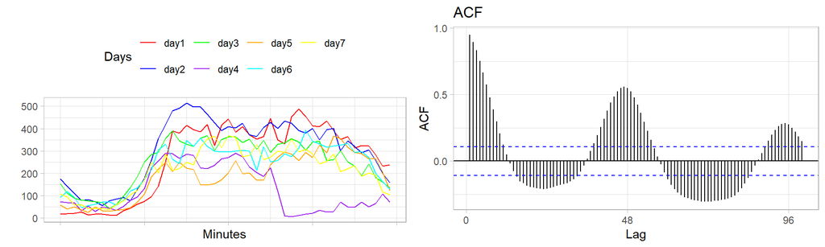

```
##
##  Box-Ljung test
##
## data:  neg_ts30
## X-squared = 304.45, df = 1, p-value < 2.2e-16
```

#### **Granularità di 1 ora:**

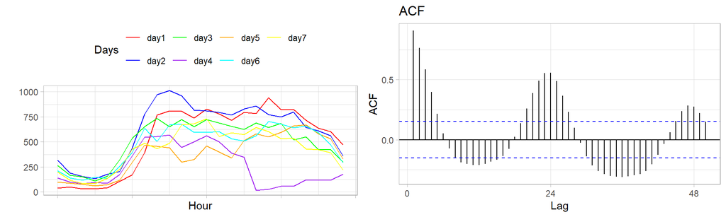

```
##
##  Box-Ljung test
##
## data:  neg_ts1h
## X-squared = 141.51, df = 1, p-value < 2.2e-16
```

### Tweet Neutrali

#### **Granularità di 10 minuti:**

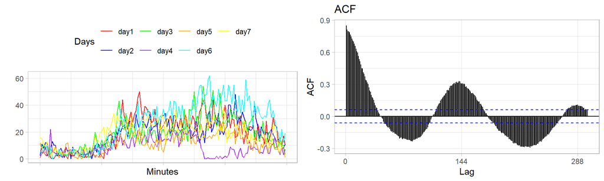

```
##
##  Box-Ljung test
##
## data:  neu_ts10
## X-squared = 727.55, df = 1, p-value < 2.2e-16
```

#### **Granularità di 30 minuti:**

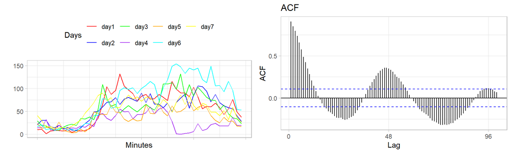

[output not shown]

#### **Granularità di 1 ora:**

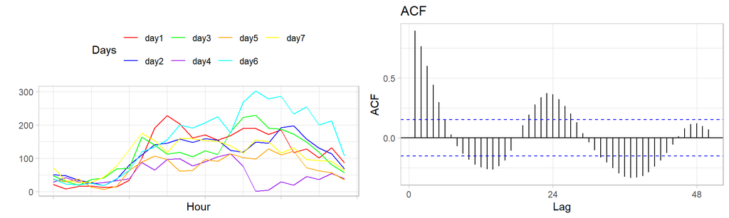

[output not shown]

### Tweet Positivi

#### **Granularità di 10 minuti:**

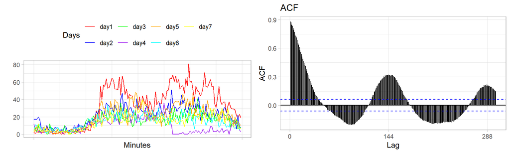

```
##
##  Box-Ljung test
##
## data:  pos_ts10
## X-squared = 781.91, df = 1, p-value < 2.2e-16
```

#### **Granularità di 30 minuti:**

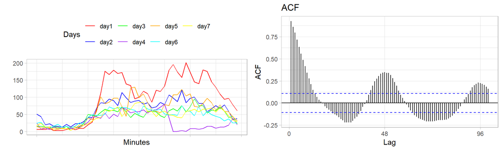

[output not shown]

#### **Granularità di 1 ora:**

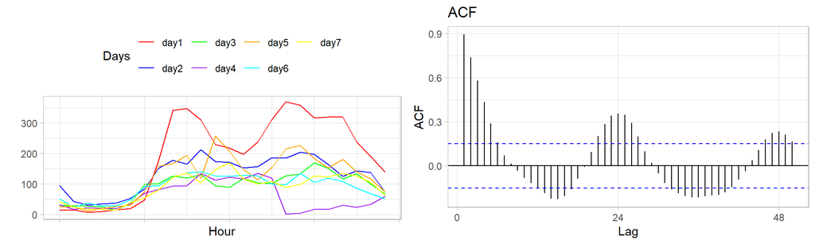

[output not shown]

Si nota chiaramente una presenza di periodicità nei dati, inoltre il test Ljung-Box che valuta se le correlazioni rilevate nei ritardi sono significative, è sempre significativo (se il p-value è piccolo <0.05) ciò indica che ci sono correlazioni significative nei dati dovute alla struttura periodica sottostante.

## Modelli Statistici (Solo serie Negativa)

Cerchiamo il miglior modello statisco che sappia descrivere la serie storica.

### Modelli di Decomposizione

#### Decomposizione STL

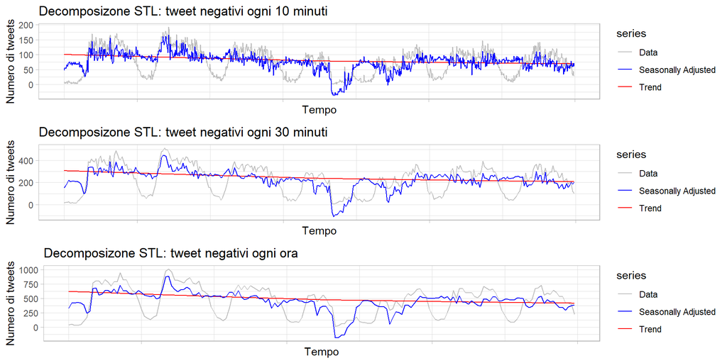

#### Decomposizione Classica Additiva

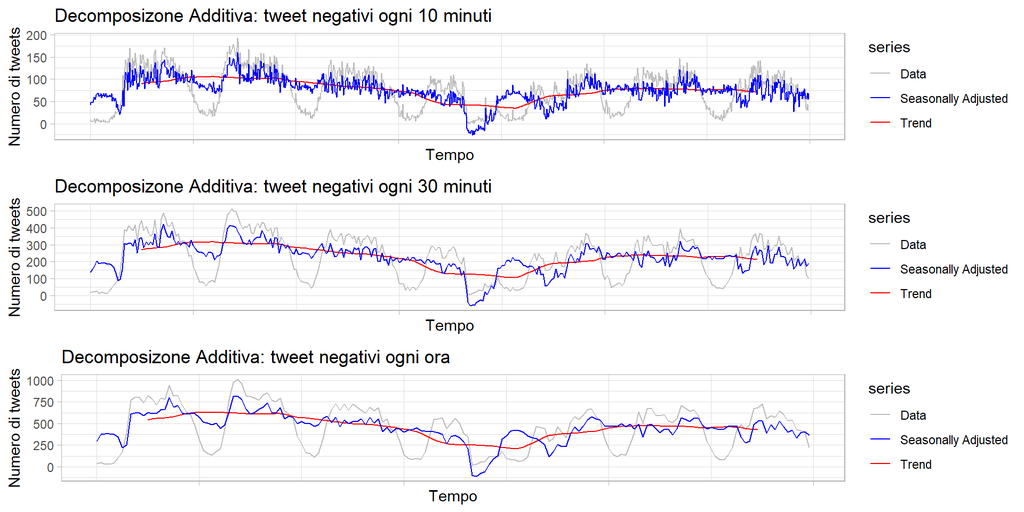

#### Decomposizione Classica Moltiplicativa

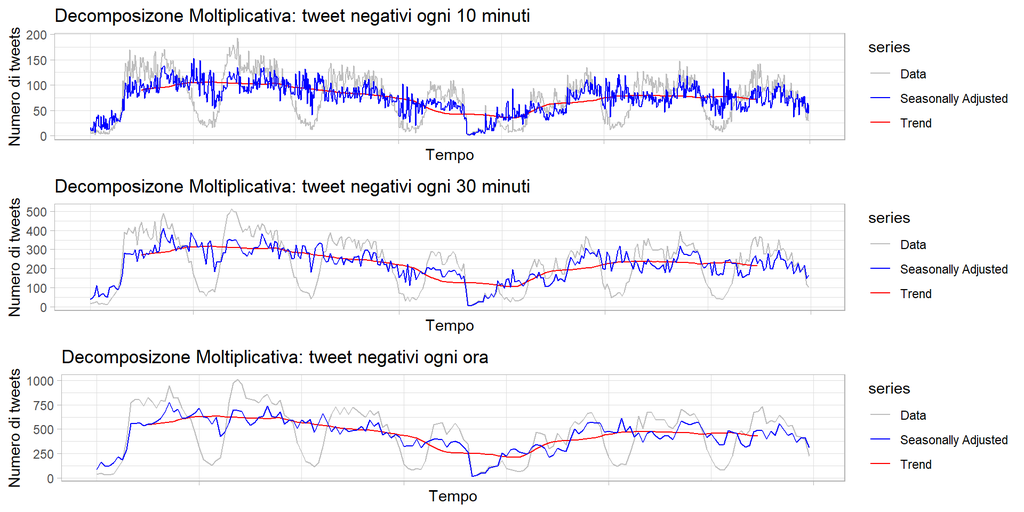

#### Decomposizione Personalizzata: Termini di Fourier + Media mobile

```
## Il miglior valore di K per la frequenza di 10 minuti è: 5
```

```
## Il miglior valore di K per la frequenza di 30 minuti è: 2
```

```
## Il miglior valore di K per la frequenza di 1 ora è: 2
```

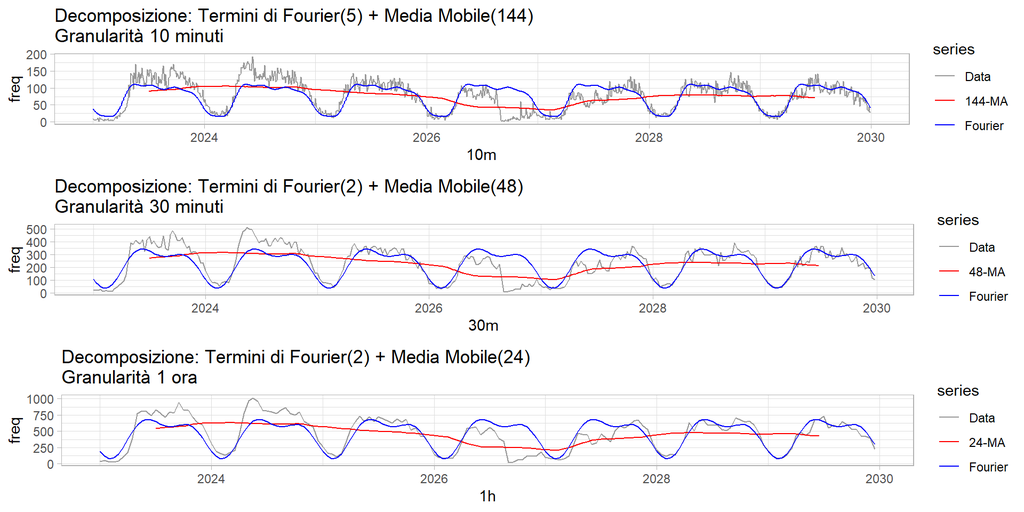

Osserviamo ora i modelli completi:

- **Modello per serie con frequenza di 10 minuti**

```
##
## Call:
## tslm(formula = neg_ts10 ~ fourier_terms10 + ma(neg_ts10, 144))
##
## Residuals:
##     Min      1Q  Median      3Q     Max
## -63.865 -11.187   0.071  13.398  60.763
##
## Coefficients:
##                        Estimate Std. Error t value Pr(>|t|)
## (Intercept)            -2.61896    2.78409  -0.941 0.347133
## fourier_terms10S1-144 -22.86256    1.00845 -22.671  < 2e-16 ***
## fourier_terms10C1-144 -33.10825    1.00793 -32.848  < 2e-16 ***
## fourier_terms10S2-144 -21.73355    1.00770 -21.568  < 2e-16 ***
## fourier_terms10C2-144  -0.09854    1.00761  -0.098 0.922116
## fourier_terms10S3-144  -1.10326    1.00764  -1.095 0.273869
## fourier_terms10C3-144   4.56257    1.00757   4.528 6.79e-06 ***
## fourier_terms10S4-144   2.78159    1.00763   2.761 0.005895 **
## fourier_terms10C4-144  -1.29959    1.00757  -1.290 0.197463
## fourier_terms10S5-144  -3.38716    1.00759  -3.362 0.000809 ***
## fourier_terms10C5-144  -2.77401    1.00758  -2.753 0.006028 **
## ma(neg_ts10, 144)       1.04116    0.03537  29.438  < 2e-16 ***
## ---
## Signif. codes:  0 '***' 0.001 '**' 0.01 '*' 0.05 '.' 0.1 ' ' 1
##
## Residual standard error: 20.94 on 852 degrees of freedom
##   (144 osservazioni eliminate a causa di valori mancanti)
## Multiple R-squared:  0.7768, Adjusted R-squared:  0.774
## F-statistic: 269.6 on 11 and 852 DF,  p-value: < 2.2e-16
```

- **Modello per serie con frequenza di 30 minuti**

```
##
## Call:
## tslm(formula = neg_ts30 ~ fourier_terms30 + ma(neg_ts30, 48))
##
## Residuals:
##      Min       1Q   Median       3Q      Max
## -175.231  -29.826    1.759   37.733  135.626
##
## Coefficients:
##                       Estimate Std. Error t value Pr(>|t|)
## (Intercept)           -8.35819   13.60743  -0.614    0.540
## fourier_terms30S1-48 -72.77097    4.92813 -14.766   <2e-16 ***
## fourier_terms30C1-48 -96.20427    4.92609 -19.530   <2e-16 ***
## fourier_terms30S2-48 -64.66605    4.92467 -13.131   <2e-16 ***
## fourier_terms30C2-48   5.29174    4.92432   1.075    0.283
## ma(neg_ts30, 48)       1.04338    0.05762  18.107   <2e-16 ***
## ---
## Signif. codes:  0 '***' 0.001 '**' 0.01 '*' 0.05 '.' 0.1 ' ' 1
##
## Residual standard error: 59.09 on 282 degrees of freedom
##   (48 osservazioni eliminate a causa di valori mancanti)
## Multiple R-squared:  0.7954, Adjusted R-squared:  0.7918
## F-statistic: 219.3 on 5 and 282 DF,  p-value: < 2.2e-16
```

- **Modello per serie con frequenza di 1 ora**

```
##
## Call:
## tslm(formula = neg_ts1h ~ fourier_terms1h + ma(neg_ts1h, 24))
##
## Residuals:
##     Min      1Q  Median      3Q     Max
## -346.57  -55.95   14.28   79.22  238.47
##
## Coefficients:
##                        Estimate Std. Error t value Pr(>|t|)
## (Intercept)           -17.31815   37.24378  -0.465   0.6427
## fourier_terms1hS1-24 -157.45281   13.47703 -11.683  < 2e-16 ***
## fourier_terms1hC1-24 -182.18729   13.47345 -13.522  < 2e-16 ***
## fourier_terms1hS2-24 -125.20897   13.46833  -9.297 2.89e-16 ***
## fourier_terms1hC2-24   26.99948   13.46789   2.005   0.0469 *
## ma(neg_ts1h, 24)        1.04470    0.07886  13.247  < 2e-16 ***
## ---
## Signif. codes:  0 '***' 0.001 '**' 0.01 '*' 0.05 '.' 0.1 ' ' 1
##
## Residual standard error: 114.3 on 138 degrees of freedom
##   (24 osservazioni eliminate a causa di valori mancanti)
## Multiple R-squared:  0.8086, Adjusted R-squared:  0.8017
## F-statistic: 116.6 on 5 and 138 DF,  p-value: < 2.2e-16
```

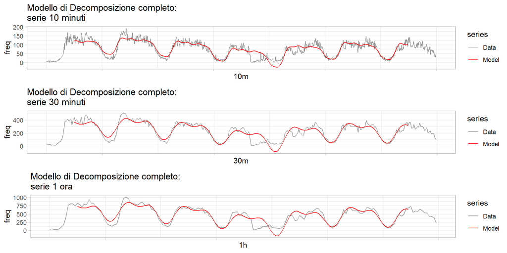

### Valutazione dei modelli

- **Valutazione modelli di decomposizione per serie storica con granularità 10 minuti**

```
##                       MAE      RMSE       MAPE
## Additiva       15.5022549 20.315863  82.477384
## Moltiplicativa  0.9993023  1.040818   2.142772
## STL            18.2296666 27.693507 128.247705
## Fourier        15.9671131 20.796078  83.687793
```

- **Valutazione modelli di decomposizione per serie storica con granularità 30 minuti**

```
##                       MAE      RMSE       MAPE
## Additiva       41.5594256 55.733294 63.1127412
## Moltiplicativa  0.9992753  1.031818  0.7050087
## STL            50.3195188 79.343839 99.7076991
## Fourier        43.8857127 58.470493 63.9946000
```

- **Valutazione modelli di decomposizione per serie storica con granularità 1 ora**

```
##                       MAE       RMSE       MAPE
## Additiva       78.9907407 107.366665 59.3151242
## Moltiplicativa  0.9991792   1.028164  0.3493459
## STL            96.3808458 155.226157 94.2074875
## Fourier        83.7240166 111.865350 60.3685127
```